# Practical Machine Learning - Course Writeup

One Dollar

November 21, 2015

# Introduction

This report analyzes the telemetry from devices like the *Jawbone Up*, *Nike FuelBand* and *Fitbit*. The data for this report comes from http://groupware.les.inf.puc-rio.br/har - in the study, 6 participants were asked to perform barbell lifts correctly and incorrectly.

The data from the accelerometers on the belt, forearm, arm and dumbell was classified and is available for training at the following location: https://d396qusza40orc.cloudfront.net/predmachlearn/pml-training.csv.

The test data for this report is available at the following location: https://d396qusza40orc.cloudfront.net/predmachlearn/pml-testing.csv

# Loading data

The data is initially loaded into two data structures - trainingOrig and testOrig.

```r
library(RCurl, quietly=TRUE)
trainingUrl = "https://d396qusza40orc.cloudfront.net/predmachlearn/pml-training.csv"
testUrl = "https://d396qusza40orc.cloudfront.net/predmachlearn/pml-testing.csv"
trainingContent = getURL(trainingUrl)
testContent = getURL(testUrl)
trainingOrig = read.csv(textConnection(trainingContent), strip.white=TRUE, stringsAsFactors=FALSE)
testOrig = read.csv(textConnection(testContent), strip.white=TRUE, stringsAsFactors=FALSE)
```

# Cleaning data

A quick look at the data reveals that a lot of columns are empty, null or NAs. We remove these columns as well as any columns related to time, since our analysis is not w.r.t windows but is a classification of the data at a given instant.

```r
dropColumnIndices = function(data)
{
  droppedColIndices = numeric()
  numColumns = dim(data)[2]
  for (i in 1:numColumns)
  {
    numNulls = sum(is.null(data[,i]))
    numNas = sum(is.na(data[,i]))
    numEmpty = sum(data[,i] == "")
    if (numNulls > 0 || numNas > 0 || numEmpty > 0)
    {
      droppedColIndices = c(droppedColIndices, i)
    }
  }
  droppedColIndices = c(droppedColIndices, 1) #X
  droppedColIndices = c(droppedColIndices, 2) #user_name
  droppedColIndices = c(droppedColIndices, 3) #raw_timestamp_part_1
  droppedColIndices = c(droppedColIndices, 4) #raw_timestamp_part_2
  droppedColIndices = c(droppedColIndices, 5) #cvtd_timestamp
  droppedColIndices = c(droppedColIndices, 6) #new_window
  droppedColIndices = c(droppedColIndices, 7) #num_window

  return (droppedColIndices)
}
dropColumns = dropColumnIndices(trainingOrig)
print(paste("Number of dropped columns = ", length(dropColumns)))
```

```
## [1] "Number of dropped columns =  107"
```

```r
training = trainingOrig[,-dropColumns]
test = testOrig[, -dropColumns]
```

# Training and model creation

We start by splitting the clean training data into two sets - 60% to be used for training and 40% to be used for testing. A model is trained using all the predictors and this model is evaluated over the test set. The original test set (test after cleaning) is kept for cross validation and will not be used before the model is finalized.

```r
splitVector = sample(1:dim(training)[1], 0.6 * dim(training)[1])
training2 = training[splitVector,]
test2 = training[-splitVector,]
library(randomForest, quietly=TRUE)
model = randomForest(factor(classe) ~ ., data=training2, importance=TRUE)
res = predict(model, test2)
res_prob = predict(model,test2, type="prob")
library(caret, quietly=TRUE)
confusionMatrix(res, test2$classe)
```

```
## Confusion Matrix and Statistics
##
##           Reference
## Prediction    A    B    C    D    E
##          A 2224   12    0    0    0
##          B    0 1495   15    0    0
##          C    0    5 1371   23    0
##          D    0    0    0 1286    8
##          E    0    0    0    0 1410
##
## Overall Statistics
##
##                Accuracy : 0.992
##                  95% CI : (0.9897, 0.9938)
##     No Information Rate : 0.2833
##     P-Value [Acc > NIR] : < 2.2e-16
##
##                   Kappa : 0.9899
##  Mcnemar's Test P-Value : NA
##
## Statistics by Class:
##
##                      Class: A Class: B Class: C Class: D Class: E
## Sensitivity            1.0000   0.9888   0.9892   0.9824   0.9944
## Specificity            0.9979   0.9976   0.9957   0.9988   1.0000
## Pos Pred Value         0.9946   0.9901   0.9800   0.9938   1.0000
## Neg Pred Value         1.0000   0.9973   0.9977   0.9965   0.9988
## Prevalence             0.2833   0.1926   0.1766   0.1668   0.1807
## Detection Rate         0.2833   0.1905   0.1747   0.1638   0.1796
## Detection Prevalence   0.2849   0.1924   0.1782   0.1649   0.1796
## Balanced Accuracy      0.9989   0.9932   0.9924   0.9906   0.9972
```

As seen from the confusion matrix, this model has high accuracy. However, this model has a lot of predictors, let us see if we can simplify it without any appreciable loss in accuracy.

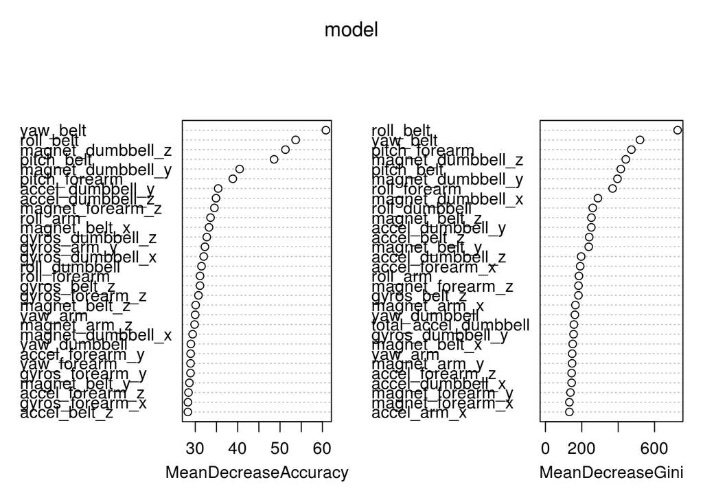

```r
varImpPlot(model)
```

```r
correlation = cor(training2[,c("yaw_belt", "roll_belt", "magnet_dumbbell_z", "pitch_belt", "magnet_dumbbell_y", "pitch_forearm", "roll_arm", "roll_forearm", "magnet_dumbbell_x")])
diag(correlation) <- 0
which(abs(correlation)>0.75, arr.ind=TRUE)
```

```
##                   row col
## roll_belt           2   1
## yaw_belt            1   2
## magnet_dumbbell_x   9   5
## magnet_dumbbell_y   5   9
```

```r
correlation[which(abs(correlation)>0.75, arr.ind=TRUE)]
```

```
## [1]  0.8173022  0.8173022 -0.7692197 -0.7692197
```

As seen above, roll_belt and yaw_belt are highly correlated, as are magnet_dumbbell_x and magnet_dumbbell_y. Let us retrain the model after keeping just the most important, uncorrelated predictors.

```r
training2 = training2[, c("classe", "yaw_belt", "magnet_dumbbell_z", "pitch_belt", "magnet_dumbbell_y", "pitch_forearm", "roll_arm", "roll_forearm")]
test2 = test2[, c("classe", "yaw_belt", "magnet_dumbbell_z", "pitch_belt", "magnet_dumbbell_y", "pitch_forearm", "roll_arm", "roll_forearm")]
library(randomForest, quietly=TRUE)
model = randomForest(factor(classe) ~ ., data=training2)
res = predict(model, test2)
library(caret, quietly=TRUE)
confusionMatrix(res, test2$classe)
```

```
## Confusion Matrix and Statistics
##
##           Reference
## Prediction    A    B    C    D    E
##          A 2213   18    0    0    0
##          B    7 1468   12    4   12
##          C    2   20 1366   11    4
##          D    2    1    8 1290    7
##          E    0    5    0    4 1395
##
## Overall Statistics
##
##                Accuracy : 0.9851
##                  95% CI : (0.9822, 0.9877)
##     No Information Rate : 0.2833
##     P-Value [Acc > NIR] : < 2.2e-16
##
##                   Kappa : 0.9812
##  Mcnemar's Test P-Value : NA
##
## Statistics by Class:
##
##                      Class: A Class: B Class: C Class: D Class: E
## Sensitivity            0.9951   0.9709   0.9856   0.9855   0.9838
## Specificity            0.9968   0.9945   0.9943   0.9972   0.9986
## Pos Pred Value         0.9919   0.9767   0.9736   0.9862   0.9936
## Neg Pred Value         0.9980   0.9931   0.9969   0.9971   0.9964
## Prevalence             0.2833   0.1926   0.1766   0.1668   0.1807
## Detection Rate         0.2819   0.1870   0.1740   0.1644   0.1777
## Detection Prevalence   0.2842   0.1915   0.1787   0.1666   0.1789
## Balanced Accuracy      0.9959   0.9827   0.9899   0.9914   0.9912
```

# Estimating out of sample error

R’s randomForest model provides an easy way to estimate the out of sample error - printing the model provides us with an estimate of the out of sample error.

```r
print(model)
```

```
##
## Call:
##  randomForest(formula = factor(classe) ~ ., data = training2)
##                Type of random forest: classification
##                      Number of trees: 500
## No. of variables tried at each split: 2
##
##         OOB estimate of  error rate: 1.34%
## Confusion matrix:
##      A    B    C    D    E class.error
## A 3335   18    1    2    0 0.006257449
## B   22 2223   32    6    2 0.027133479
## C    1   15 2006   13    1 0.014734774
## D    0    1   12 1892    2 0.007865758
## E    0   11    8   11 2159 0.013704888
```

# Evaluating the test set

The original test set (test) was kept aside as a cross validation set. The results of evaluating the test set against the model trained so far are as follows:

```r
res = predict(model, test)
res
```

```
##  1  2  3  4  5  6  7  8  9 10 11 12 13 14 15 16 17 18 19 20
##  B  A  B  A  A  E  D  B  A  A  B  C  B  A  E  E  A  B  B  B
## Levels: A B C D E
```